# SQL Workshop

Oscar O’Brien

2023-05-14

# SQL

- SQL == Structured Query Language
- Made by IBM in 1974 to handle large datasets
- Works with data in 3 ways:
  - Query
  - Maintenance
  - Definition

| **Category** | **Statement** | **Purpose** |
| --- | --- | --- |
| *Query* | Select | Display rows of table(s) |
| *Maintenance* | Insert | Add rows to a table |
|  | Update | Change rows in a table |
|  | Delete | Remove rows from a table |
| *Definition* | Create | Add tables |
|  | Drop | Remove tables |

# Definitions

Here is a very basic query structure:

```r
SELECT columns
FROM table
WHERE comparisons
```

- Keywords: reserved special words
  - SELECT, FROM, WHERE, etc…
  - SELECT == select == SeLEcT (but usually uppercase)
- Clauses: are name after their keywords
  - SELECT clause, FROM clause, WHERE clause
  - Typically each clause gets its own line for readability, but not necessary
- Parameters: variable part of clauses
  - Ex: specific column names, values, etc…

# Table Structure

- Data is stored similar to the tidy format from R
  - Rows are individual observations
  - Columns are variables
  - Cells are values
- Normalization in SQL is the process of reducing data redundancy
  - Typically, data is stored across multiple tables
  - The relationship of the data dictates table structure
- Keys are columns that are used to join tables
  - Primary keys uniquely identify rows
    - Composite keys occur when multiple columns identify a row
  - Foreign keys are primary keys stored outside of their primary table

## Basic Table Example

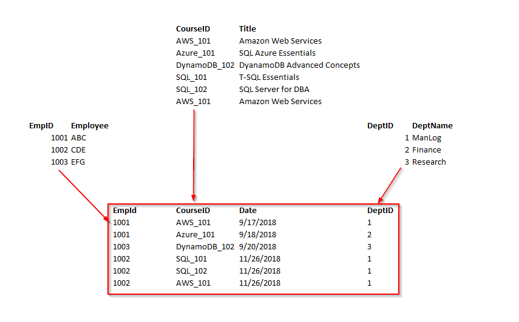

## Basic Relationships

- One:Many
  - Add a table to store repeated information by referencing its key
  - Shown in the example above
- Many:Many
  - Create a “transaction” table to store keys from two tables

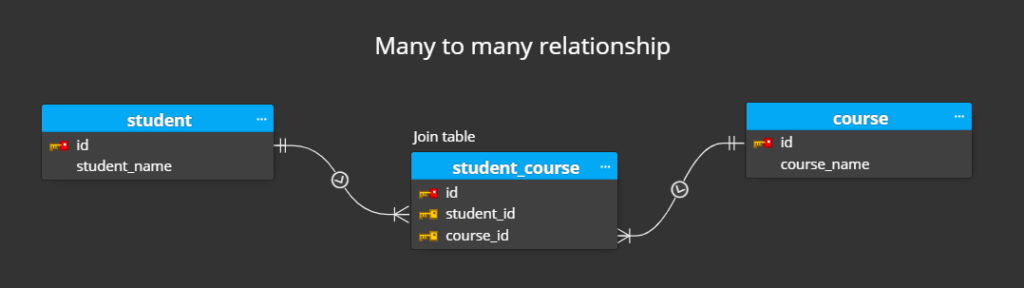

# Getting Started with SQL in R

```r
# install.packages("DBI")
library(DBI)
```

- DBI is an interface with these database backends:
  - RPostgres
  - RMariaDB
  - RSQLite
  - odbc
  - bigrquery
  - and more

# Creating a temporary table in memory

```r
# opening a connection
con <- dbConnect(RSQLite::SQLite(), dbname = ":memory:")

# creating a new table from a dataframe
dbWriteTable(con, "mtcars", mtcars)
```

- Here we open a connection to a SQLite database in memory
  - Usually you provide username, password, host, port to connect to online server
- con is initially empty, so we write the built-in mtcars table to a table called “mtcars”

## A More Realistic Connection

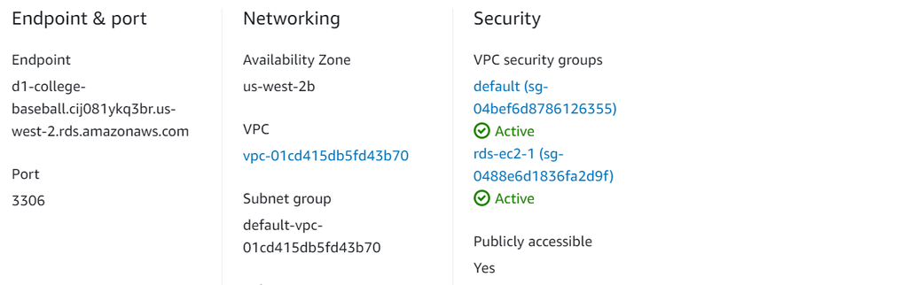

- This is a SQL endpoint from AWS

## Connection Continued

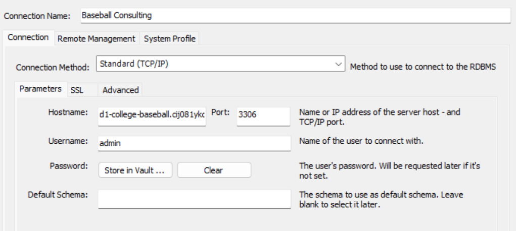

- This information is used in MySQL to connect to data not stored locally

# Basic Functionality

```r
dbListTables(con) # list tables
```

```
## [1] "mtcars"
```

```r
dbListFields(con, "mtcars") # list columns of mtcars table
```

```
##  [1] "mpg"  "cyl"  "disp" "hp"   "drat" "wt"   "qsec" "vs"   "am"   "gear"
## [11] "carb"
```

```r
dbReadTable(con, "mtcars") # show data from mtcars table
```

```
##     mpg cyl  disp  hp drat    wt  qsec vs am gear carb
## 1  21.0   6 160.0 110 3.90 2.620 16.46  0  1    4    4
## 2  21.0   6 160.0 110 3.90 2.875 17.02  0  1    4    4
## 3  22.8   4 108.0  93 3.85 2.320 18.61  1  1    4    1
## 4  21.4   6 258.0 110 3.08 3.215 19.44  1  0    3    1
## 5  18.7   8 360.0 175 3.15 3.440 17.02  0  0    3    2
## 6  18.1   6 225.0 105 2.76 3.460 20.22  1  0    3    1
## 7  14.3   8 360.0 245 3.21 3.570 15.84  0  0    3    4
## 8  24.4   4 146.7  62 3.69 3.190 20.00  1  0    4    2
## 9  22.8   4 140.8  95 3.92 3.150 22.90  1  0    4    2
## 10 19.2   6 167.6 123 3.92 3.440 18.30  1  0    4    4
## 11 17.8   6 167.6 123 3.92 3.440 18.90  1  0    4    4
## 12 16.4   8 275.8 180 3.07 4.070 17.40  0  0    3    3
## 13 17.3   8 275.8 180 3.07 3.730 17.60  0  0    3    3
## 14 15.2   8 275.8 180 3.07 3.780 18.00  0  0    3    3
```

[output cut: 18 more lines]

# Writing Basic Queries

```r
sql <- "
  SELECT *
  FROM mtcars
  LIMIT 5
"

query <- dbSendQuery(con, sql)
dbFetch(query)
```

```
##    mpg cyl disp  hp drat    wt  qsec vs am gear carb
## 1 21.0   6  160 110 3.90 2.620 16.46  0  1    4    4
## 2 21.0   6  160 110 3.90 2.875 17.02  0  1    4    4
## 3 22.8   4  108  93 3.85 2.320 18.61  1  1    4    1
## 4 21.4   6  258 110 3.08 3.215 19.44  1  0    3    1
## 5 18.7   8  360 175 3.15 3.440 17.02  0  0    3    2
```

- The `*` is a special symbol for all columns

## Similarly, …

```r
dbClearResult(query)

sql <- "
  SELECT *
  FROM mtcars
"

query <- dbSendQuery(con, sql)
dbFetch(query, n = 5)
```

```
##    mpg cyl disp  hp drat    wt  qsec vs am gear carb
## 1 21.0   6  160 110 3.90 2.620 16.46  0  1    4    4
## 2 21.0   6  160 110 3.90 2.875 17.02  0  1    4    4
## 3 22.8   4  108  93 3.85 2.320 18.61  1  1    4    1
## 4 21.4   6  258 110 3.08 3.215 19.44  1  0    3    1
## 5 18.7   8  360 175 3.15 3.440 17.02  0  0    3    2
```

- You can specify how many rows to retrieve in `dbFetch()`
  - The default behavior is `n=-1`

## Selecting Specific Columns

```r
dbClearResult(query)

sql <- "
  SELECT mpg, cyl AS cylinders, hp AS horsepower
  FROM mtcars
"

query <- dbSendQuery(con, sql)
dbFetch(query, n = 5)
```

```
##    mpg cylinders horsepower
## 1 21.0         6        110
## 2 21.0         6        110
## 3 22.8         4         93
## 4 21.4         6        110
## 5 18.7         8        175
```

- Separate columns with a comma
- Column output can be renamed with `AS`

## Selecting Unique Values

```r
dbClearResult(query)

sql <- "
  SELECT DISTINCT cyl AS cylinders
  FROM mtcars
"

query <- dbSendQuery(con, sql)
dbFetch(query)
```

```
##   cylinders
## 1         6
## 2         4
## 3         8
```

- Use the keyword `DISTINCT` to find the unique values in a column

# Filtering Rows

```r
dbClearResult(query)

sql <- "
  SELECT mpg, cyl AS cylinders, hp AS horsepower
  FROM mtcars
  WHERE mpg > 20 AND cyl = 6 AND hp <>  90
"

query <- dbSendQuery(con, sql)
dbFetch(query, n = 5)
```

```
##    mpg cylinders horsepower
## 1 21.0         6        110
## 2 21.0         6        110
## 3 21.4         6        110
```

- The results display only rows where the WHERE clause evaluates to TRUE (removes missing values)
- Not equals works with `<>` and `!=` (in this SQL version)
- Test for equivalence with a single `=`

## More Filtering Details

- Place non-numeric date in quotes `''`
  - `WHERE country = 'United States'`
  - `WHERE date = '2023-05-14'`
- `OR` can be used instead of `AND`
- To check for missing values use `IS NULL` or `IS NOT NULL`
- For negation, use the keyword `NOT`

## More Filtering

```r
dbClearResult(query)

sql <- "
  SELECT mpg, cyl AS cylinders, hp AS horsepower
  FROM mtcars
  WHERE cyl IN (4, 6)
"

query <- dbSendQuery(con, sql)
dbFetch(query, n = 5)
```

```
##    mpg cylinders horsepower
## 1 21.0         6        110
## 2 21.0         6        110
## 3 22.8         4         93
## 4 21.4         6        110
## 5 18.1         6        105
```

- `IN` is more concise than `cyl = 4 OR cyl = 6`

## Even More Filtering

```r
dbClearResult(query)

sql <- "
  SELECT mpg, cyl AS cylinders, hp AS horsepower
  FROM mtcars
  WHERE mpg BETWEEN 10 AND 20
"

query <- dbSendQuery(con, sql)
dbFetch(query, n = 5)
```

```
##    mpg cylinders horsepower
## 1 18.7         8        175
## 2 18.1         6        105
## 3 14.3         8        245
## 4 19.2         6        123
## 5 17.8         6        123
```

- `BETWEEN` is more concise than `MPG > 10 AND MPG < 20`

# Ordering Results

```r
dbClearResult(query)

sql <- "
  SELECT mpg, cyl AS cylinders, hp AS horsepower
  FROM mtcars
  ORDER BY mpg
"

query <- dbSendQuery(con, sql)
dbFetch(query, n = 5)
```

```
##    mpg cylinders horsepower
## 1 10.4         8        205
## 2 10.4         8        215
## 3 13.3         8        245
## 4 14.3         8        245
## 5 14.7         8        230
```

- The default ordering is ascending

## Descending Order

```r
dbClearResult(query)

sql <- "
  SELECT mpg, cyl AS cylinders, hp AS horsepower
  FROM mtcars
  ORDER BY mpg DESC
"

query <- dbSendQuery(con, sql)
dbFetch(query, n = 5)
```

```
##    mpg cylinders horsepower
## 1 33.9         4         65
## 2 32.4         4         66
## 3 30.4         4         52
## 4 30.4         4        113
## 5 27.3         4         66
```

- Use the `DESC` keyword

## Ordering by Multiple Columns

```r
dbClearResult(query)

sql <- "
  SELECT mpg, cyl AS cylinders, hp AS horsepower
  FROM mtcars
  ORDER BY mpg DESC, cyl
"

query <- dbSendQuery(con, sql)
dbFetch(query, n = 10)
```

```
##     mpg cylinders horsepower
## 1  33.9         4         65
## 2  32.4         4         66
## 3  30.4         4         52
## 4  30.4         4        113
## 5  27.3         4         66
## 6  26.0         4         91
## 7  24.4         4         62
## 8  22.8         4         93
## 9  22.8         4         95
## 10 21.5         4         97
```

- The results with be sorted by mpg descending
- For equal mpg values, the cyl values with by sorted in ascending order

# Basic Arithmetic Expressions

```r
dbClearResult(query)

sql <- "
  SELECT mpg + cyl, cyl - drat, (disp * carb) / qsec
  FROM mtcars
  ORDER BY mpg + cyl
"

query <- dbSendQuery(con, sql)
dbFetch(query, n = 5)
```

```
##   mpg + cyl cyl - drat (disp * carb) / qsec
## 1      18.4       5.07            105.00556
## 2      18.4       5.00            103.25477
## 3      21.3       4.27             90.85010
## 4      22.3       4.79             90.90909
## 5      22.7       4.77            101.03330
```

- `+-*/()` all work as expected
- Calculates values per row by default
- Creates new columns for the results
  - Columns can be renamed

# Aggregate Functions

```r
dbClearResult(query)

sql <- "
  SELECT COUNT(*), SUM(cyl), MIN(mpg), MAX(mpg), AVG(hp) AS avg_hp
  FROM mtcars
"

query <- dbSendQuery(con, sql)
dbFetch(query, n = 5)
```

```
##   COUNT(*) SUM(cyl) MIN(mpg) MAX(mpg)   avg_hp
## 1       32      198     10.4     33.9 146.6875
```

- `SUM()`, `MIN()`, `MAX()`, `AVG()` work as expected
- `COUNT()` is tricky
  - `COUNT(*)` counts all rows
  - `COUNT(mpg)` counts all non empty rows in `mpg`
  - `COUNT(DISTINCT mpg)` counts all distinct values in `mpg`

# Grouping Results

```r
dbClearResult(query)

sql <- "
  SELECT cyl, AVG(hp) AS avg_hp
  FROM mtcars
  GROUP BY cyl
"

query <- dbSendQuery(con, sql)
dbFetch(query, n = 5)
```

```
##   cyl    avg_hp
## 1   4  82.63636
## 2   6 122.28571
## 3   8 209.21429
```

- Non grouped columns must be in aggregate functions

## Grouping by Multiple Columns

```r
dbClearResult(query)

sql <- "
  SELECT cyl, vs, AVG(hp) AS avg_hp
  FROM mtcars
  GROUP BY cyl, vs
  ORDER BY avg_hp DESC
"

query <- dbSendQuery(con, sql)
dbFetch(query)
```

```
##   cyl vs   avg_hp
## 1   8  0 209.2143
## 2   6  0 131.6667
## 3   6  1 115.2500
## 4   4  0  91.0000
## 5   4  1  81.8000
```

- Groups by cyl first, then vs
  - Similar to `ORDER BY` clause from earlier
- Ordering happens at the end, so can use calculated columns

## Filtering Grouped Results

```r
dbClearResult(query)

sql <- "
  SELECT cyl, vs, AVG(hp) AS avg_hp
  FROM mtcars
  GROUP BY cyl, vs
  HAVING avg_hp > 100
"

query <- dbSendQuery(con, sql)
dbFetch(query)
```

```
##   cyl vs   avg_hp
## 1   6  0 131.6667
## 2   6  1 115.2500
## 3   8  0 209.2143
```

- `HAVING` clause is like `WHERE` clause, but happens after grouping

# Summary of Clause Order

```r
"SELECT
FROM
WHERE
GROUP BY
HAVING
ORDER BY
LIMIT"
```

- The order cannot be swapped

## Full Example

```r
dbClearResult(query)

sql <- "
  SELECT cyl, vs, AVG(hp) AS avg_hp
  FROM mtcars
  WHERE am = 1 AND gear >= 3
  GROUP BY cyl, vs
  HAVING avg_hp > 100
  ORDER BY cyl
  LIMIT 5
"

query <- dbSendQuery(con, sql)
dbFetch(query)
```

```
##   cyl vs   avg_hp
## 1   6  0 131.6667
## 2   8  0 299.5000
```

# Joining Tables

Consider a different dataset with multiple tables about flights in and out of NYC

```r
dbDisconnect(con)
# install.packages(nycflights13)
library(nycflights13)

flights_subset <- nycflights13::flights[1:2000, ]

con <- dbConnect(RSQLite::SQLite(), dbname = ":memory:")
dbWriteTable(con, "flights", flights_subset)
dbWriteTable(con, "airports", nycflights13::airports)
```

- We will consider the flights and airports tables

## Flight Data Structure

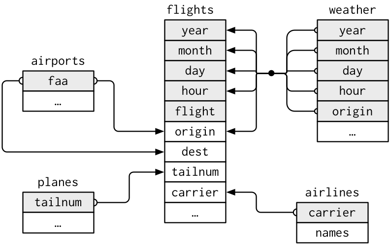

## Types of Joins

[figure not shown]

## Join Example

```r
sql <- "
  SELECT month, day, dep_time, origin, dest
  FROM flights AS f
    INNER JOIN airports AS a ON a.faa = f.dest
  WHERE tzone = 'America/Chicago'
  LIMIT 10
"

query <- dbSendQuery(con, sql)
dbFetch(query)
```

```
##    month day dep_time origin dest
## 1      1   1      905    JFK  AUS
## 2      1   1     1456    EWR  AUS
## 3      1   1     1654    JFK  AUS
## 4      1   1     1701    JFK  AUS
## 5      1   1     2021    JFK  AUS
## 6      1   1     2025    EWR  AUS
## 7      1   2      636    EWR  AUS
## 8      1   2      928    JFK  AUS
## 9      1   2     1513    EWR  AUS
## 10     1   2     1657    JFK  AUS
```

- Joins need `ON` to know how to join
  - `ON` criteria can be more than 1 column
- AUS is Austin, TX

# Common Table Expressions

```r
dbClearResult(query)

sql <- "
  WITH highest_avg_delay_dest AS (
    SELECT dest, AVG(dep_delay)
    FROM flights
    WHERE dep_delay > 0
    GROUP BY dest
    LIMIT 1
  )
  SELECT f.dest, day, COUNT(*) as num_flights, SUM(dep_delay) as total_delay, AVG(dep_delay) as avg_delay
  FROM flights f
    INNER JOIN highest_avg_delay_dest hadd ON hadd.dest = f.dest
  WHERE dep_delay > 0
  GROUP BY f.dest, day
  ORDER BY day ASC
"

query <- dbSendQuery(con, sql)
dbFetch(query)
```

```
##   dest day num_flights total_delay avg_delay
## 1  ALB   1           2          86  43.00000
## 2  ALB   2           3         194  64.66667
```

- Common Table Expressions allow for queries to happen in sequence for more complex queries
- Remember the data here is a small subset, so we only get two days of data
- There are other types of sub-queries, but I like CTEs for their readability

# Exercises

Consider a smaller dataset about flowers

```r
dbDisconnect(con)
con <- dbConnect(RSQLite::SQLite(), dbname = ":memory:")

dbWriteTable(con, "iris", iris)

dbReadTable(con, "iris")
```

```
##     Sepal.Length Sepal.Width Petal.Length Petal.Width    Species
## 1            5.1         3.5          1.4         0.2     setosa
## 2            4.9         3.0          1.4         0.2     setosa
## 3            4.7         3.2          1.3         0.2     setosa
## 4            4.6         3.1          1.5         0.2     setosa
## 5            5.0         3.6          1.4         0.2     setosa
## 6            5.4         3.9          1.7         0.4     setosa
## 7            4.6         3.4          1.4         0.3     setosa
## 8            5.0         3.4          1.5         0.2     setosa
## 9            4.4         2.9          1.4         0.2     setosa
## 10           4.9         3.1          1.5         0.1     setosa
## 11           5.4         3.7          1.5         0.2     setosa
## 12           4.8         3.4          1.6         0.2     setosa
## 13           4.8         3.0          1.4         0.1     setosa
## 14           4.3         3.0          1.1         0.1     setosa
```

[output cut: 136 more lines]

## Exercise 1

How many flowers are there for each species and what is their average sepal length?

-Note: `column.name` forces SQL to consider `column.name` is a column, not as table `column` with column `name`

## Exercise 1 Solution

```r
sql <- "
  SELECT Species, COUNT(*), AVG(`Sepal.Length`) as avg_length
  FROM iris
  GROUP BY Species
"

query <- dbSendQuery(con, sql)
dbFetch(query)
```

```
##      Species COUNT(*) avg_length
## 1     setosa       50      5.006
## 2 versicolor       50      5.936
## 3  virginica       50      6.588
```

## Exercise 2

Which rows have the sum of sepal length, sepal width, petal length, petal width larger than 10 order by petal length descending and limit to 10 results?

## Exercise 2 Solution

```r
dbClearResult(query)

sql <- "
  SELECT *
  FROM iris
  WHERE (`Sepal.Length` + `Sepal.Width` + `Petal.Length` + `Petal.Width`) > 10
  ORDER BY `Petal.Length` DESC
  LIMIT 10
"

query <- dbSendQuery(con, sql)
dbFetch(query)
```

```
##    Sepal.Length Sepal.Width Petal.Length Petal.Width   Species
## 1           7.7         2.6          6.9         2.3 virginica
## 2           7.7         3.8          6.7         2.2 virginica
## 3           7.7         2.8          6.7         2.0 virginica
## 4           7.6         3.0          6.6         2.1 virginica
## 5           7.9         3.8          6.4         2.0 virginica
## 6           7.3         2.9          6.3         1.8 virginica
## 7           7.2         3.6          6.1         2.5 virginica
## 8           7.4         2.8          6.1         1.9 virginica
## 9           7.7         3.0          6.1         2.3 virginica
## 10          6.3         3.3          6.0         2.5 virginica
```

## Exercise 3

What two species of have highest sepal length to sepal width ratio?

## Exercise 3 Solution

```r
dbClearResult(query)

sql <- "
  SELECT Species, `Sepal.Length`/`Sepal.Width` AS ratio
  FROM iris
  GROUP BY Species
  ORDER BY ratio DESC
  LIMIT 2
"

query <- dbSendQuery(con, sql)
dbFetch(query)
```

```
##      Species    ratio
## 1 versicolor 2.187500
## 2  virginica 1.909091
```

# Conclusion

- We learned:
  - the purpose of SQL
  - SQL’s basic functions
  - how data is stored
  - how to query databases with `SELECT`
- Not covered:
  - maintaining tables
  - defining tables

# Bonus

SQL Murder Mystery

https://mystery.knightlab.com/

# References

- https://cdncontribute.geeksforgeeks.org/wp-content/uploads/SQL-Manual.pdf
- https://dbi.r-dbi.org/